# M9/Final

Git In

Sarah Figueroa

Git In

12/11/2021

## Introduction

Trans-Gulf migrants (TGMs) travel long distances to forage and breed. These birds migrate from Central and South America every spring to more temperate regions between Texas and Florida. Their time of arrival to the breeding grounds have differing tradeoffs and can affect the fitness of the migrants.

## Methods

In order to study the effect of local weather conditions on the arrival time of TGMs in Massachusetts, the meteorological data from Mobible AL, Charlotte NC, and Boston MA were acquired from NOAA’s National Climatic Data Center’s API to examine five species of birds (Hylocichla mustelina, Archilochus colubris, Seiurus aurocapilla, Progne subis, and Icterus galbula) from eBird.

```r
dat%>%
  group_by(year,species)%>%
  summarise(count=sum(individualCount,na.rm = T))%>%
  ggplot(aes(x=year,y=count,col=species))+geom_point()
```

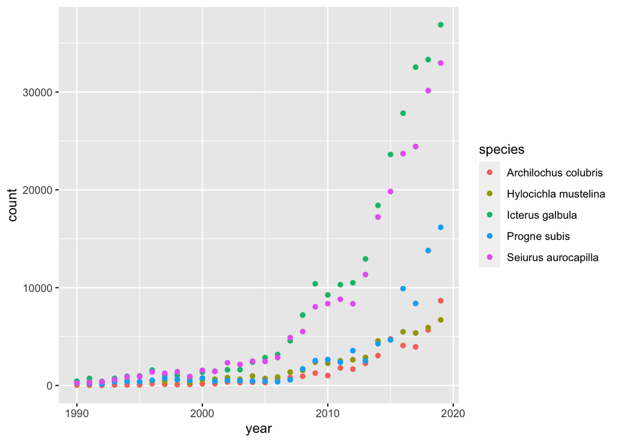

[figure not shown]

[output not shown]

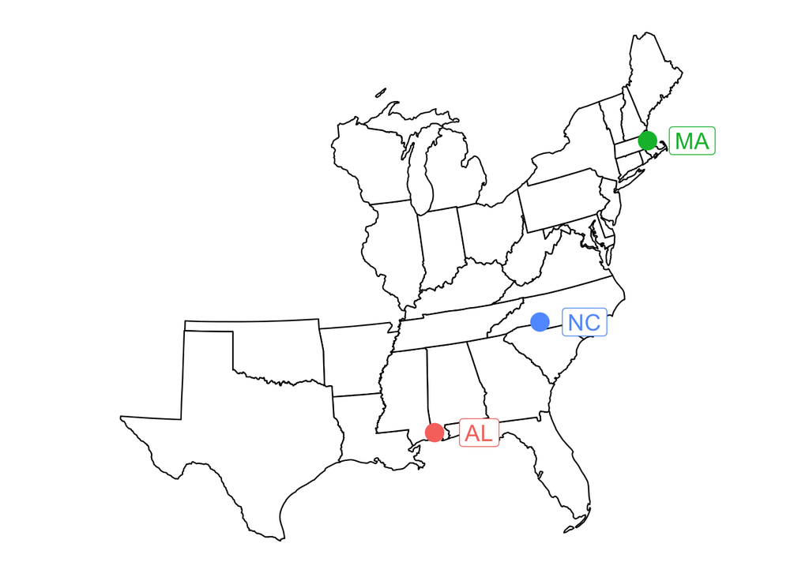

[figure not shown]

[output not shown]

```
## date created (size, mb): 2021-12-14 16:16:30 (7.062)
```

```
## file min/max dates: 1948-01-01 / 2021-12-31
```

[output not shown]

```
## date created (size, mb): 2021-12-14 16:17:03 (7.66)
```

```
## file min/max dates: 1939-07-01 / 2021-12-31
```

[output not shown]

```
## date created (size, mb): 2021-12-14 16:17:38 (8.492)
```

```
## file min/max dates: 1936-01-01 / 2021-12-31
```

[figure not shown]

[figure not shown]

[figure not shown]

[figure not shown]

```r
arrivals<- dat%>%
  group_by(species, year)%>%
  mutate(date=as.Date(paste0(year,"-",month,"-",day)), j.day=julian(date,origin=as.Date(paste0(unique(year),"-01-01"))))%>%
  group_by(species,year,j.day,date)%>%
  summarise(day.tot=sum(individualCount,na.rm=T))%>%
  group_by(species,year)%>%
  mutate(prop=cumsum(day.tot/sum(day.tot,na.rm = T)))%>%
  filter(year>1999)
```

```r
arrivals.pred <- arrivals%>%
  group_by(species,year)%>%
 summarize(
   pred=predict(nls(prop~SSlogis(j.day,Asym, xmid, scal)),newdata=data.frame(j.day=min(j.day):max(j.day))),#predict the logistic curve for each species
   j.day=min(j.day):max(j.day),
  )%>%
  left_join(arrivals%>%select(j.day,date)) ## add date back to tibble
arrivals%>%
  ggplot(aes(j.day,prop, col=species))+geom_point(aes=0.3)+geom_line(data=arrivals.pred,aes(x=j.day,y=pred),size=2)+facet_wrap(year~.)
```

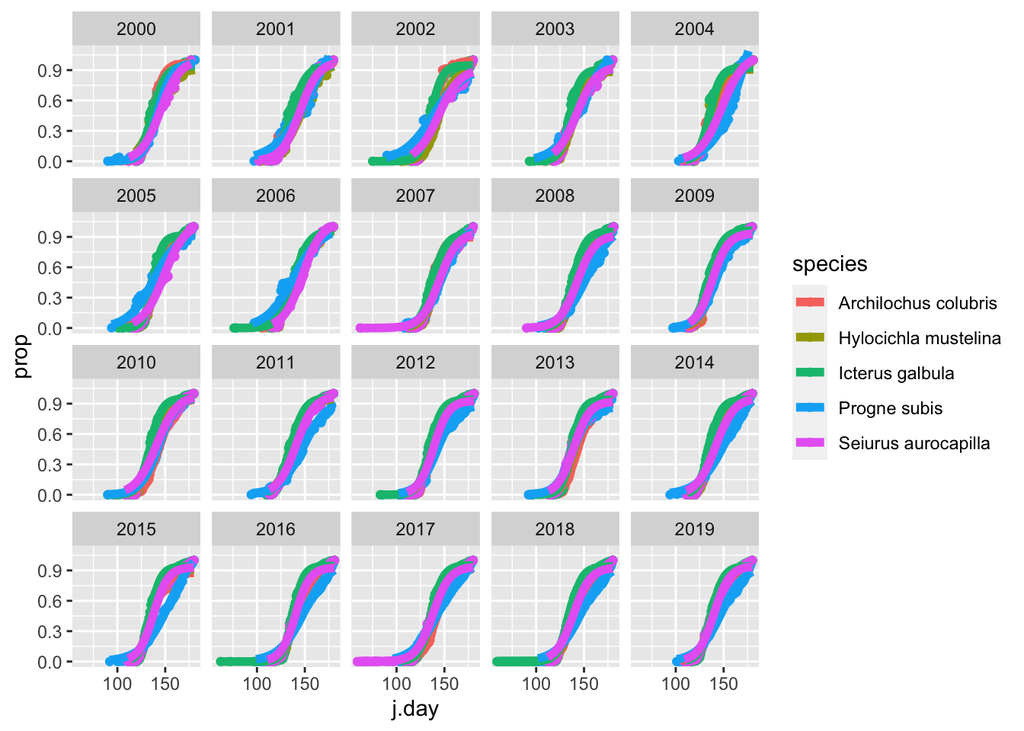

[figure not shown]

```r
arrival.date <-arrivals.pred%>%
  group_by(species, year)%>%
  filter(j.day==j.day[which.min(abs(pred-0.25))])

weather.d <- weather.d%>%
  dplyr::mutate(year=as.integer(str_sub(date,1,4)), #add year
         date=as.Date(date))%>%
  group_by(year)%>% #group by year so we can compute julian day
  dplyr::mutate(j.day=julian(date,origin=as.Date(paste0(unique(year),"-01-01"))), #add julian day
  date2=date,
  wdir.rad=(180-abs(wdf2-180))*pi/180, #radians so we can use a trig function to compute wind vector, scale degrees first to 180 scale to 2x pi and subtract from 180 (wind comes out of a direction)
  wvec=cos(wdir.rad)*-1*awnd # we want a negative value for positive value for 2x pi
  )%>% #store day in new column
  select(id,year,date2,j.day,tmin,tmax,wvec)%>% #select the rows we need
  left_join(sta.d%>%select(id,name,migr.day))%>% #add the station id info (ie. name)
  mutate(j.day=j.day+migr.day)#make j.day ahead of BOS according to the migration days away so we can join weather along path
arrival.weath <- arrival.date%>%
  left_join(weather.d)%>%
  left_join(arrivals%>%select(year,date,j.day))
weather.wk <-weather.d %>%
  group_by(year,name) %>%
  mutate(wk.tmin = frollmean(tmin, n=14,align="right"),
         wk.tmax = frollmean(tmax, n=14,align="right"),
         wk.wvec = frollmean(wvec, n=14,align="right")
         )%>%
  select(j.day,date2,name,wk.tmin,wk.tmax,wk.wvec)
arrivals.weath2 <- arrival.date%>%
  left_join(weather.wk)
options(noaakey = "eOXSnLpzEZBYwjYJqQwwgBMMFLBbxGWz")
sts <- c(
  "GHCND:USW00013894", #Mobible, AL 2k away about 10 days away @200 km/day
  "GHCND:USW00013881", #Charlotte, NC 1000 km away about 6 days away @200 km/day
  "GHCND:USW00014739" #Boston
)
bos <- ncdc_stations(stationid = "GHCND:USW00014739")

print(bos)
```

```
## $meta
## NULL
##
## $data
##   elevation    mindate    maxdate latitude          name datacoverage
## 1       3.7 1936-01-01 2021-12-08  42.3606 BOSTON, MA US            1
##                  id elevationUnit longitude
## 1 GHCND:USW00014739        METERS  -71.0097
##
## attr(,"class")
## [1] "ncdc_stations"
```